# Assessment of Air Quality Models in Cities of India

The result summaries of the VAR model fitting function.

```r
summary(var.a)
```

```
##
## VAR Estimation Results:
## =========================
## Endogenous variables: so2, no2, rspm, pm2_5
## Deterministic variables: none
## Sample size: 687
## Log Likelihood: -9885.379
## Roots of the characteristic polynomial:
## 0.9989 0.9522 0.9366 0.9366 0.9129 0.9129 0.901 0.901 0.8698 0.8698 0.8591 0.8543 0.8543 0.8534 0.8534 0.8364 0.8364 0.8265 0.8265 0.8201 0.8201 0.818 0.818 0.8172 0.7786 0.7786 0.7488 0.7488 0.7344 0.7344 0.6504 0.6504 0.6469 0.6469 0.6283 0.6283 0.5885 0.5885 0.4312 0.4312
## Call:
## vars::VAR(y = MP_train, type = "none", lag.max = 10, ic = "AIC")
##
##
## Estimation results for equation so2:
## ====================================
## so2 = so2.l1 + no2.l1 + rspm.l1 + pm2_5.l1 + so2.l2 + no2.l2 + rspm.l2 + pm2_5.l2 + so2.l3 + no2.l3 + rspm.l3 + pm2_5.l3 + so2.l4 + no2.l4 + rspm.l4 + pm2_5.l4 + so2.l5 + no2.l5 + rspm.l5 + pm2_5.l5 + so2.l6 + no2.l6 + rspm.l6 + pm2_5.l6 + so2.l7 + no2.l7 + rspm.l7 + pm2_5.l7 + so2.l8 + no2.l8 + …
##
##             Estimate Std. Error t value Pr(>|t|)
## so2.l1     0.0737711  0.0408596   1.805  0.07146 .
## no2.l1    -0.0151899  0.0144956  -1.048  0.29508
## rspm.l1   -0.0029998  0.0076003  -0.395  0.69320
## pm2_5.l1   0.0428606  0.0137445   3.118  0.00190 **
## so2.l2    -0.1113537  0.0404752  -2.751  0.00610 **
## no2.l2    -0.0221615  0.0146376  -1.514  0.13051
## rspm.l2   -0.0062148  0.0076672  -0.811  0.41791
## pm2_5.l2   0.0299608  0.0139131   2.153  0.03165 *
## so2.l3     0.1805275  0.0405507   4.452 1.00e-05 ***
## no2.l3    -0.0077278  0.0146953  -0.526  0.59916
## rspm.l3   -0.0027751  0.0077145  -0.360  0.71917
## pm2_5.l3  -0.0055842  0.0140882  -0.396  0.69196
## so2.l4     0.0744491  0.0404456   1.841  0.06612 .
## no2.l4     0.0311736  0.0137125   2.273  0.02333 *
## rspm.l4   -0.0010772  0.0076933  -0.140  0.88869
## pm2_5.l4  -0.0102234  0.0139813  -0.731  0.46491
## so2.l5     0.0401478  0.0405373   0.990  0.32235
## no2.l5    -0.0052745  0.0135000  -0.391  0.69614
## rspm.l5   -0.0019014  0.0077023  -0.247  0.80509
## pm2_5.l5   0.0117671  0.0139392   0.844  0.39888
## so2.l6    -0.0692658  0.0405880  -1.707  0.08838 .
## no2.l6    -0.0186062  0.0133056  -1.398  0.16248
```

[output cut: 188 more lines]

```
##
##
## Covariance matrix of residuals:
##          so2     no2   rspm  pm2_5
## so2   10.026   3.778  24.52  11.46
## no2    3.778 100.743 114.04  86.44
## rspm  24.523 114.036 756.61 356.97
## pm2_5 11.460  86.437 356.97 261.75
##
## Correlation matrix of residuals:
##          so2    no2   rspm  pm2_5
## so2   1.0000 0.1189 0.2816 0.2237
## no2   0.1189 1.0000 0.4130 0.5323
## rspm  0.2816 0.4130 1.0000 0.8021
## pm2_5 0.2237 0.5323 0.8021 1.0000
```

We will use Granger test for causality where the null hypothesis is the lagged x-values do not explain the variation in y. In other words, it assumes that independent variable does not cause the dependent variable. All variable of multivariate time series have to be stationary for causality function to give reliable results.

```r
causality(var.a, #VAR model
          cause = c("pm2_5")) #dependent variable. If not specified then first column of x is used. Multiple variables can be used.
```

```
## $Granger
##
##  Granger causality H0: pm2_5 do not Granger-cause so2 no2 rspm
##
## data:  VAR object var.a
## F-Test = 1.9128, df1 = 30, df2 = 2588, p-value = 0.002057
##
##
## $Instant
##
##  H0: No instantaneous causality between: pm2_5 and so2 no2 rspm
##
## data:  VAR object var.a
## Chi-squared = 281.02, df = 3, p-value < 2.2e-16
```

Since the model is adequate, we proceed with forecasting and plot the forecast.

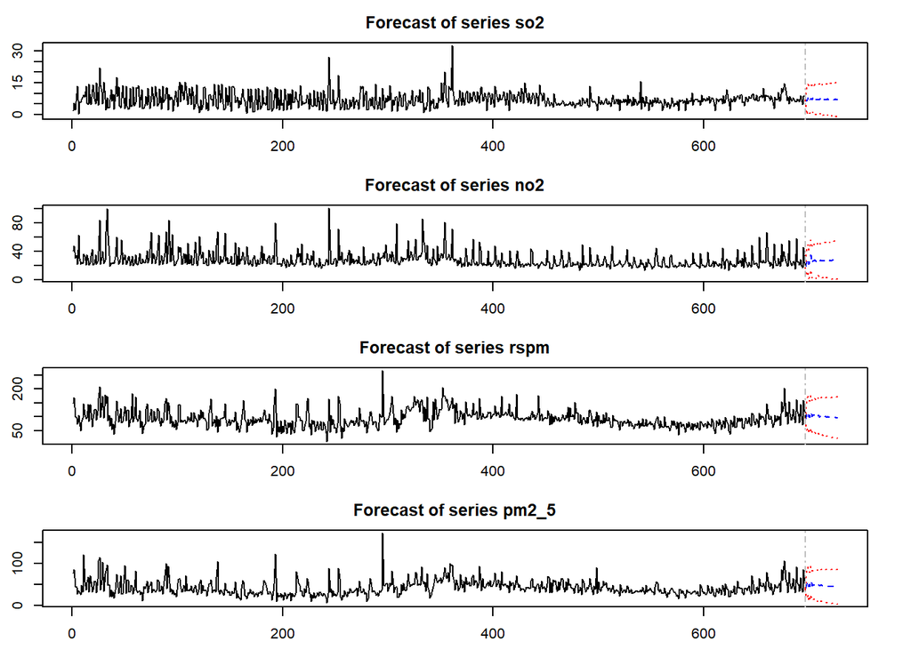

```r
fcast = predict(var.a, n.ahead =30) # we forecast over a month
par(mar = c(2.5,2.5,2.5,2.5))
plot(fcast)
```

We continue with evaluation.

```r
f.val= fcast$fcst$pm2_5[,1]
a.val= MP_test[['pm2_5']] # the accuracy requires numeric vector only.
accuracy(f.val,a.val)
```

```
##                ME     RMSE      MAE       MPE     MAPE
## Test set 0.252317 16.24965 10.75093 -7.730103 21.35858
```

### Clustering

Besides time series modelling, we also do a clustering to identify cities (location) with similar air quality. We cluster them by using only the latest 1 year (2015-01-01 to 2015-12-31) of data, with the mean value of numerical variables (SO2, NO2, RSPM, SPM, PM2.5) as the features.

First we import relevant library. We then filter the recent data and obtain the features mentioned above:

```r
library(cluster)
library(lubridate)

start_date<- ymd("2015-01-01")
rec_clus_data<- df[df$date > start_date, ]

### remove rows with missing location
rec_clus_data<- rec_clus_data[!is.na(rec_clus_data$location), ]

loc_data<- rec_clus_data %>% group_by(location) %>%
  summarise(mean_so2 = mean(so2, na.rm=TRUE),
            mean_no2 = mean(no2, na.rm=TRUE),
            mean_rspm = mean(rspm, na.rm=TRUE),
            mean_spm = mean(spm, na.rm=TRUE),
            mean_pm2_5 = mean(pm2_5, na.rm=TRUE)
  ) %>% data.frame()

head(loc_data)
```

```
##    location  mean_so2  mean_no2 mean_rspm mean_spm mean_pm2_5
## 1      Agra  3.689055 20.822761 180.28234      NaN        NaN
## 2 Ahmedabad 13.230435 20.847826  89.25217      NaN   28.63913
## 3    Aizawl  2.001890  8.385633  44.10208      NaN        NaN
## 4     Akola  7.247191  8.378277 127.19476      NaN        NaN
## 5 Alappuzha  2.000000  5.000000  45.33613      NaN        NaN
## 6 Allahabad  3.608511 28.486692 250.65399      NaN        NaN
```

Next we check and handle the missing values.

```r
num_loc = nrow(loc_data)

for (col in colnames(loc_data) ){
  num_na<- sum(is.na(loc_data[col]))
  perc_na<- round(100*num_na/num_loc, digits=2)
  print(paste(col, num_na, perc_na))
}
```

```
## [1] "location 0 0"
## [1] "mean_so2 4 1.57"
## [1] "mean_no2 3 1.18"
## [1] "mean_rspm 0 0"
## [1] "mean_spm 254 100"
## [1] "mean_pm2_5 191 75.2"
```

We see that SPM (100%) and PM2.5 (75.2%) have very large amount of missing values. We can only drop these features as imputing them will introduce large bias in the clustering model. For SO2 and NO2, we will impute using mean value.

```r
loc_data$mean_so2[is.na(loc_data$mean_so2)]= mean(loc_data$mean_so2, na.rm = TRUE)
loc_data$mean_no2[is.na(loc_data$mean_no2)]= mean(loc_data$mean_no2, na.rm = TRUE)

#### set location as row names
rownames(loc_data)<- loc_data$location

#### drop unnecessary columns
clean_loc_data<- loc_data %>% dplyr::select(-c(mean_spm, mean_pm2_5, location))

head(clean_loc_data)
```

```
##            mean_so2  mean_no2 mean_rspm
## Agra       3.689055 20.822761 180.28234
## Ahmedabad 13.230435 20.847826  89.25217
## Aizawl     2.001890  8.385633  44.10208
## Akola      7.247191  8.378277 127.19476
## Alappuzha  2.000000  5.000000  45.33613
## Allahabad  3.608511 28.486692 250.65399
```

Before clustering the data, we need to scale the features so that their magnitude are of the same order.

```r
scaled_loc_data<- clean_loc_data
for (mean_col in colnames(scaled_loc_data)){
 scaled_loc_data[mean_col]<- scale(scaled_loc_data[mean_col], center=TRUE, scale=TRUE)
}
```

Now we can do clustering. We use the elbow method to obtain a suitable number of clusters, k.

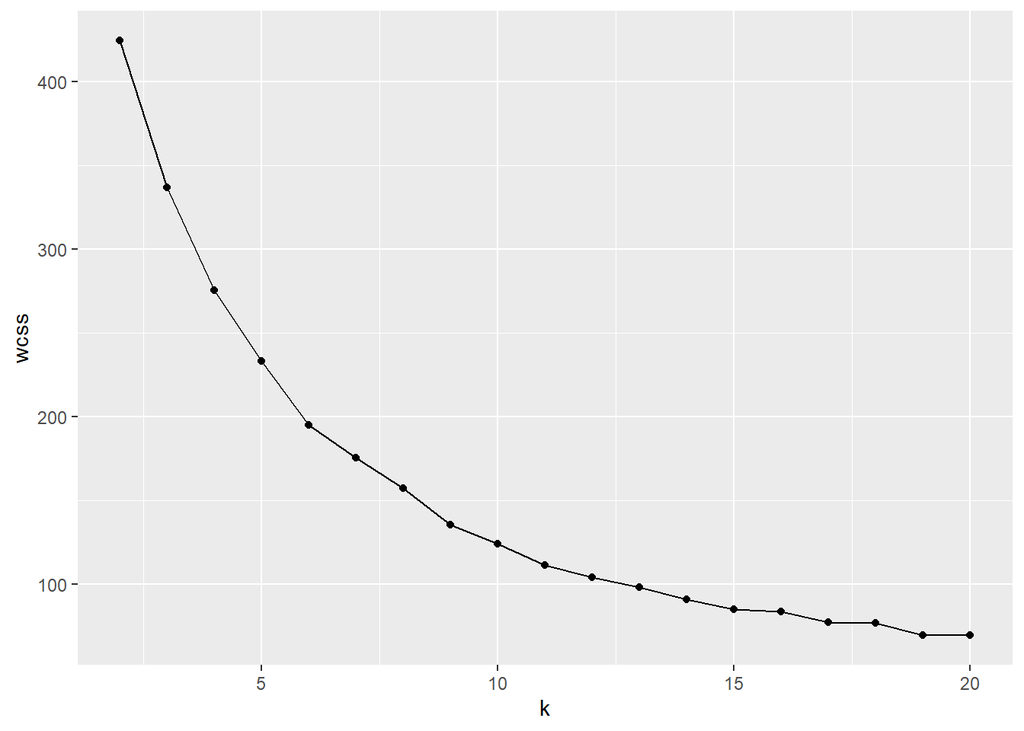

```r
max_k<- 20
wcss<- rep(NA, max_k-1)

for (k in c(2:max_k)){
  k_clus<- kmeans(scaled_loc_data, centers = k, nstart = 10)
  wcss[k-1]<- k_clus$tot.withinss
}

wcss_df<- data.frame(k=c(2:max_k), wcss = wcss)
wcss_fig<- wcss_df %>% ggplot(aes(x=k, y=wcss)) +
  geom_line() + geom_point()

print(wcss_fig)
```

Here, we see that at around k=8 the Within Cluster Sum of Squared (WCSS) value decreases slowly. Thus we will pick optimal k as 8 to do the clustering.

```r
best_k<- 8

clus_loc<- kmeans(scaled_loc_data, centers = scaled_loc_data[1:best_k,], nstart = 10)
clus_grp<- data.frame(clus_loc$cluster) %>% setNames("cluster")
merged_res<- merge(clean_loc_data, clus_grp, by ='row.names', all=TRUE)
merged_res$cluster<- as.factor(merged_res$cluster)

### center of each cluster
center_data<- merged_res %>% group_by(cluster) %>%
  summarise(num_city = n(),
            cen_mean_so2 = mean(mean_so2, na.rm=TRUE),
            cen_mean_no2 = mean(mean_no2, na.rm=TRUE),
            cen_mean_rspm = mean(mean_rspm, na.rm=TRUE),
  ) %>% data.frame()

print(center_data)
```

```
##   cluster num_city cen_mean_so2 cen_mean_no2 cen_mean_rspm
## 1       1       24     8.375138     24.87456     147.06674
## 2       2       36    13.643467     21.64344      85.97458
## 3       3       32     6.353506     25.07242      70.44578
## 4       4       57     4.864980     14.48268      98.23663
## 5       5       60     3.959786     10.03803      50.47906
## 6       6       12    12.169472     36.11782     209.11197
## 7       7       14    25.603259     31.94829     138.60601
## 8       8       19    15.276456     51.08625     109.78509
```

The above table shows the centroid for each cluster. To better visualise the difference among the clusters, we can plot the box plot of each features for the clusters:

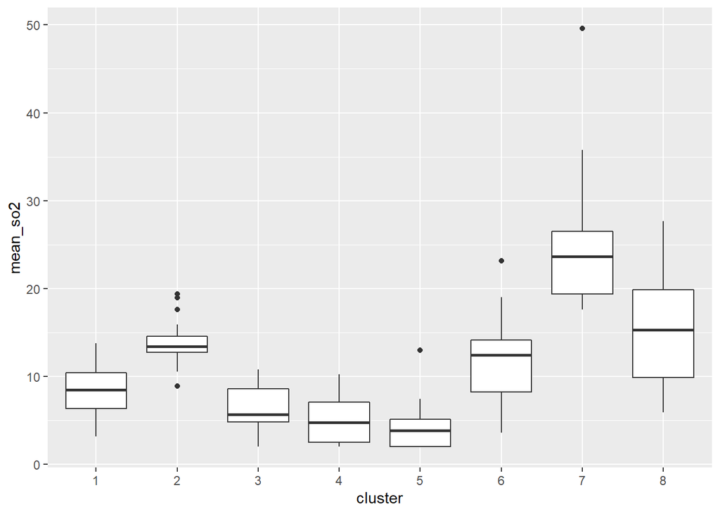

```r
clus_vis_so2<- merged_res %>% ggplot(aes(x=cluster, y=mean_so2)) +
  geom_boxplot()
print(clus_vis_so2)
```

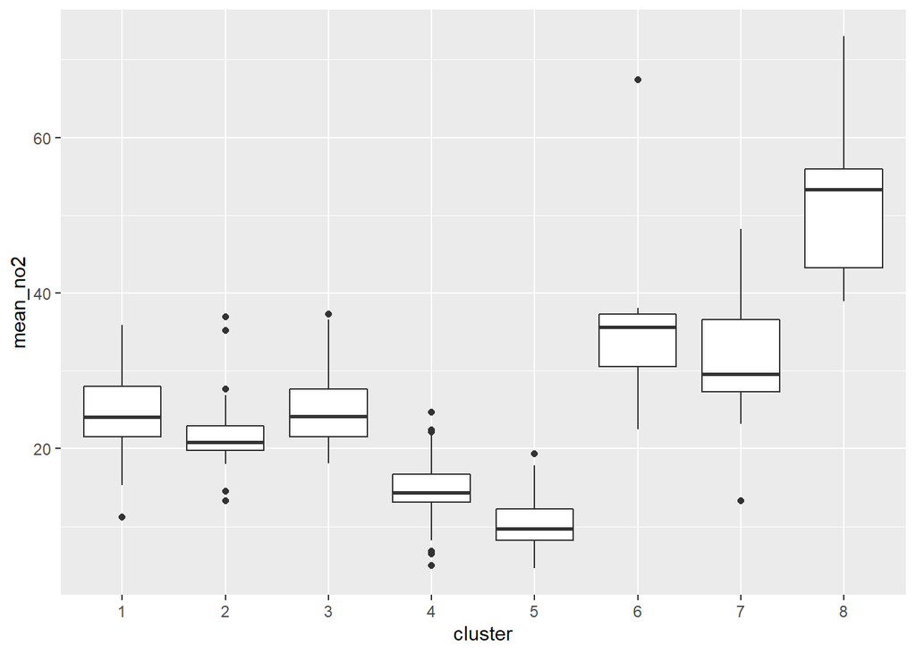

```r
clus_vis_no2<- merged_res %>% ggplot(aes(x=cluster, y=mean_no2)) +
  geom_boxplot()
print(clus_vis_no2)
```

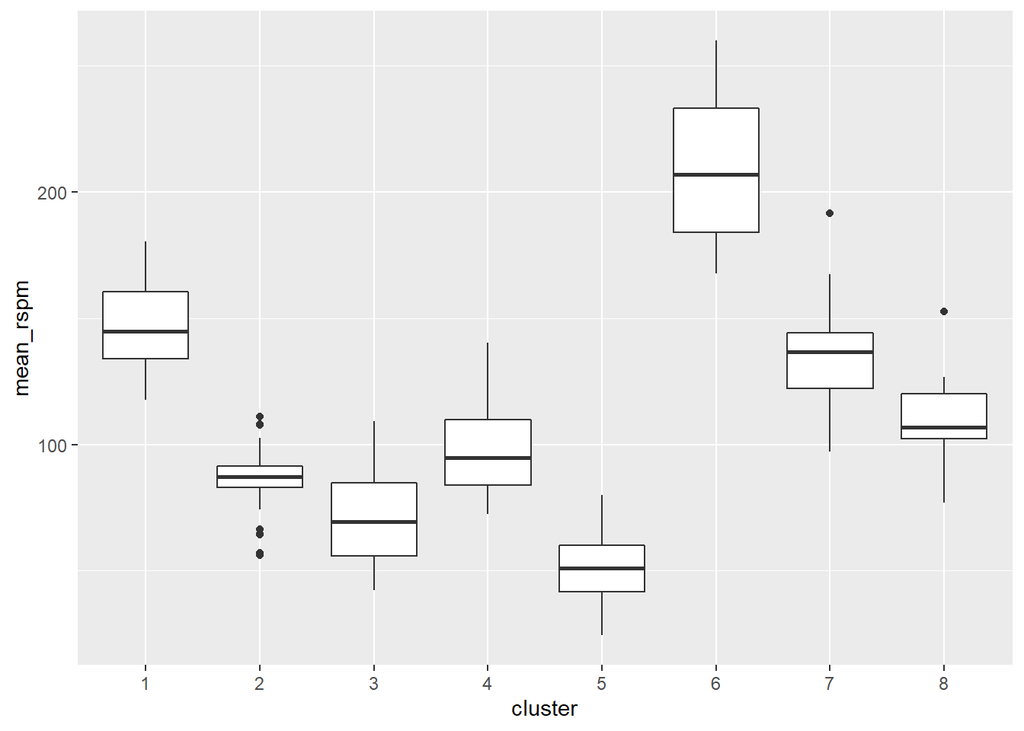

```r
clus_vis_rspm<- merged_res %>% ggplot(aes(x=cluster, y=mean_rspm)) +
  geom_boxplot()
print(clus_vis_rspm)
```

From the plot, we see that cities in cluster 6, 7 and 8 have high values in all 3 features, which represents low air quality. Interestingly, these clusters have significantly high value in exactly 1 of the feature: cluster 6 is high in RSPM, cluster 7 in SO2 and cluster 8 in NO2. For the others, cities in cluster 5 have the best air quality with lowest value in all 3 features. Cluster 1 has moderate value in SO2 and NO2 but with high RSPM, while cluster 2 is high SO2. The remaining clusters 3 and 4 have moderate value in all 3 features.

## Discussion

Upon comparing the concentrations of pollutants in various cities within India discovered that Maharashtra have most observations among other cities; in terms of type of area residential areas has the highest percentage of pollutants in air:

1. SO2 concentration of Mizoram was found to be lowest and highest was of Uttaranchal.
2. NO2 concentration of Mizoram was found to be lowest and highest was of West Bengal.
3. RSPM concentration was found critical in all cities among which low critical level was found in Sikkim and extreme critical levels were found in Uttar Pradesh and Delhi.
4. SPM concentration was found very critical in all in all cities among which low critical level was found in Sikkim and extreme critical levels were found in Delhi.
5. Mostly concentration of pollutants was found to be higher industrial areas.